# Data Description

Author: Rajat Jain

Last Updated: 2018-04-23

### Schema

We have first 7-day product usage data from Adobe photography plan users. Data is a CSV file containing 2650 rows. It has following columns:

- **member_guid:** Customer Identifier.
- **class:** Output Class - PHOTOGRAPHER or OTHER.
- **lr_cc_usage:** # of times customer used Lightroom CC product in first 7-days.
- **lr_cl_usage:** # of times customer used Lightroom Classic product in first 7-days.
- **lr_mo_usage:** # of times customer used Lightroom Mobile product in first 7-days.
- **storage_usage:** # of times customer accessed Cloud Storage in first 7-days.
- **ps_usage:** # of times customer used Photoshop product in first 7-days.
- **stock_usage:** # of times customer searched for a Stock Image in first 7-days.

### Data Summary

```
##           class       lr_cc_usage       lr_cl_usage       lr_mo_usage
##  OTHER       :1500   Min.   : 0.0000   Min.   :  0.000   Min.   : 0.00
##  PHOTOGRAPHER:1150   1st Qu.: 0.0000   1st Qu.:  0.000   1st Qu.: 0.00
##                      Median : 0.0000   Median :  2.000   Median : 0.00
##                      Mean   : 0.3475   Mean   :  4.217   Mean   : 0.86
##                      3rd Qu.: 0.0000   3rd Qu.:  6.000   3rd Qu.: 0.00
##                      Max.   :22.0000   Max.   :185.000   Max.   :24.00
##  storage_usage         ps_usage        stock_usage
##  Min.   :     0.0   Min.   :  0.000   Min.   :  0.000
##  1st Qu.:     0.0   1st Qu.:  0.000   1st Qu.:  0.000
##  Median :     0.0   Median :  3.000   Median :  0.000
##  Mean   :   300.5   Mean   :  4.649   Mean   :  1.002
##  3rd Qu.:     1.0   3rd Qu.:  6.000   3rd Qu.:  0.000
##  Max.   :107556.0   Max.   :182.000   Max.   :246.000
```

### Distribution of Class Labels

The bar chart below shows the distrubution of class labels in the input data (in absolute number of records).

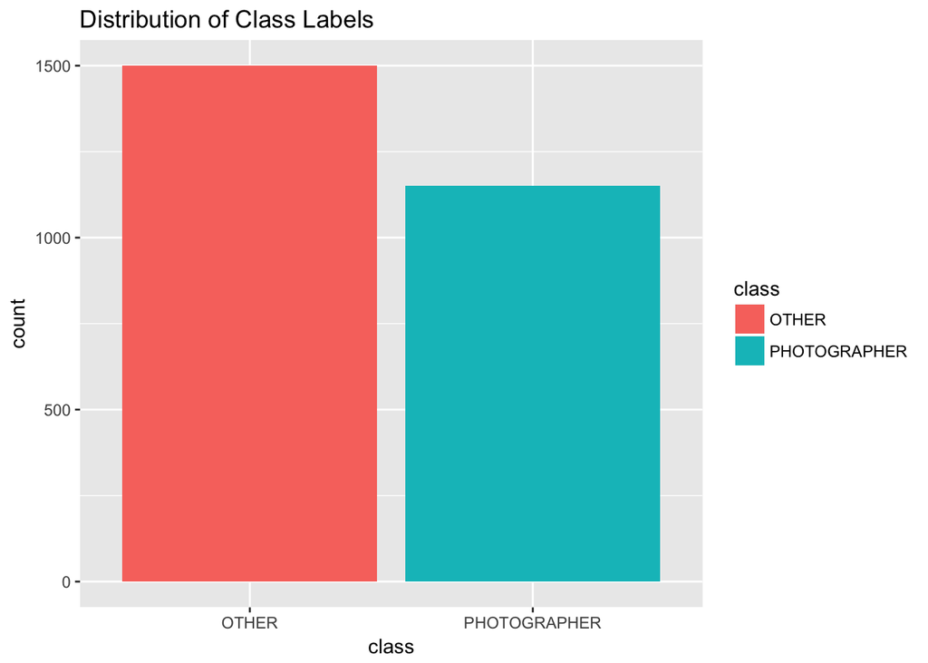

It contains **43.4%** records classfied as “PHOTOGRAPHER” class and 56.6% records in “OTHER” class.

### Binomial Test

Now we run Binomial Test on this data.

```r
binom.test(nrow(usage.data[usage.data[,2] == "PHOTOGRAPHER",]), nrow(usage.data))
```

```
##
##  Exact binomial test
##
## data:  nrow(usage.data[usage.data[, 2] == "PHOTOGRAPHER", ]) and nrow(usage.data)
## number of successes = 1150, number of trials = 2650, p-value =
## 1.127e-11
## alternative hypothesis: true probability of success is not equal to 0.5
## 95 percent confidence interval:
##  0.4149853 0.4530853
## sample estimates:
## probability of success
##              0.4339623
```